# Exploring 2016 San Diego Police Stop Data

The purpose of this R Notebook is to clean and explore the 2016 police vehicle stop data that can be found at [Open San Diego’s website](https://data.sandiego.gov/datasets/police-vehicle-stops/).

```r
library(tidyverse, verbose = F)
library(knitr, verbose = F)
library(stringr, verbose = F)
```

## About the Data

There are four datasets that we’ll be reading in, but two are for reference. The `race` dataframe describes the race codes used.

```r
race <- read_csv("http://seshat.datasd.org/pd/vehicle_stops_race_codes.csv")
```

The `dict` dataframe is a description of all the variables in the main police vehicle stop dataset.

```r
dict <- read_csv("http://seshat.datasd.org/pd/vehicle_stops_dictionary.csv")
```

This is the main vehicle stops dataset from 2016, which will require some cleaning.

```r
s_url <- "http://seshat.datasd.org/pd/vehicle_stops_2016_datasd.csv"

stops <- read_csv(s_url, col_types = cols(stop_id = col_character(),
                                          subject_age = col_character()),
                  na = "NA", progress = F)
```

A lot of the character values will need to be cleaned up, including consolidating values that were spelled differently or capitalized.

```r
# Yes and no's
stops$searched <- str_replace_all(stops$searched,
                                  c("n" = "N", "\\\\" = "", "NA" = ""))
stops$arrested <- str_replace_all(stops$arrested,
                                  c("n" = "N", "y" = "Y"))

# Remove "no age"
stops <- stops %>%
  mutate(subject_age = ifelse(subject_age == "No Age", "", subject_age),
         subject_age = as.numeric(subject_age))

# Remove X's in the gender field
stops <- stops %>%
  mutate(subject_sex = ifelse(subject_sex == "" | subject_sex == "X",
                              NA,
                              subject_sex))

# Consolidate values stop_cause
stops$stop_cause <- str_replace_all(stops$stop_cause,
                        c("Bicycle Bicycle" = "Bicycle",
                          "BICYCLE" = "bicycle",
                          "Muni, County, H&S Code" = "MUNI, County, H&S Code"))
```

Let’s examine the structure of the `stops` data.

```r
str(stops)
```

```
## Classes 'tbl_df', 'tbl' and 'data.frame':    103051 obs. of  15 variables:
##  $ stop_id         : chr  "1308198" "1308172" "1308171" "1308170" ...
##  $ stop_cause      : chr  "Equipment Violation" "Moving Violation" "Moving Violation" "Moving Violation" ...
##  $ service_area    : chr  "530" "520" "110" "Unknown" ...
##  $ subject_race    : chr  "W" "B" "H" "W" ...
##  $ subject_sex     : chr  "M" "M" "F" "F" ...
##  $ subject_age     : num  28 25 31 29 52 24 20 50 25 23 ...
##  $ timestamp       : POSIXct, format: "2016-01-01 00:06:00" "2016-01-01 00:10:00" ...
##  $ stop_date       : Date, format: "2016-01-01" "2016-01-01" ...
##  $ stop_time       :Classes 'hms', 'difftime'  atomic [1:103051] 360 600 840 960 1800 1800 2100 2700 3780 4200 ...
##   .. ..- attr(*, "units")= chr "secs"
##  $ sd_resident     : chr  "Y" "N" "" "N" ...
##  $ arrested        : chr  "N" "N" "" "N" ...
##  $ searched        : chr  "N" "N" "" "N" ...
##  $ obtained_consent: chr  "N" "" "" "" ...
##  $ contraband_found: chr  "N" "" "" "" ...
##  $ property_seized : chr  "N" "" "" "" ...
```

There’s also a dataframe that describes the actions taken during searches for each `stop_id`.

```r
d_url <- "http://seshat.datasd.org/pd/vehicle_stops_search_details_2016_datasd.csv"

details <- read_csv(d_url,
                    col_types = cols(stop_id = col_character(),
                                     search_details_id = col_character(),
                                     search_details_type = col_character(),
                                     search_details_description = col_character()))
```

[output not shown]

Doing the `left_join` with `stops` and `details` results in multiple `stop_id` matches, probably because there are multiple observations in `details` for each of the `stop_id`. The result is that new rows are created in the resulting `comb` dataset.

```r
comb <- left_join(stops, details, by = "stop_id")
dim(stops); dim(details); dim(comb)
```

```
## [1] 103051     15
```

```
## [1] 113571      4
```

```
## [1] 113591     18
```

Let’s focus first on analyzing the `stops` dataset without joining to the `details` dataset so that we don’t misrepresent the number of observations originally collected in the `stops` dataset.

## Exploratory Analysis

The following are exploratory plots to help generate hypotheses and ideas for feature selection.

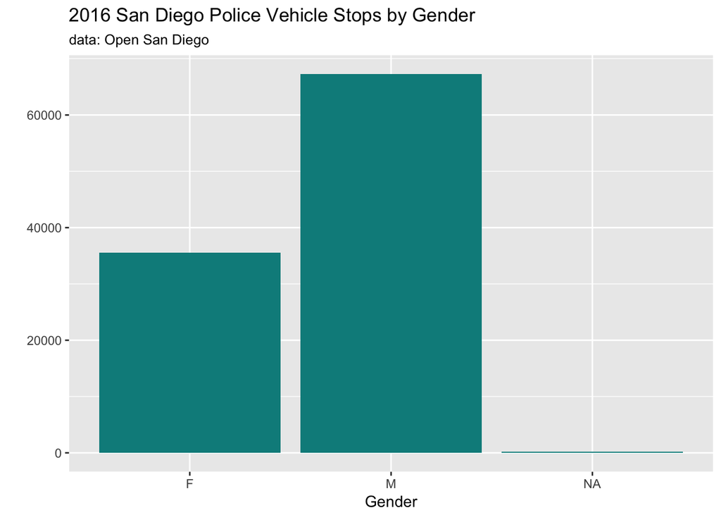

```r
ggplot(data = stops, aes(x = subject_sex)) +
  geom_bar(fill = "cyan4") +
  labs(title = "2016 San Diego Police Vehicle Stops by Gender",
       subtitle = "data: Open San Diego",
       x = "Gender",
       y = "")
```

This boxplot drops rows because of NA values in the `subject_age` column.

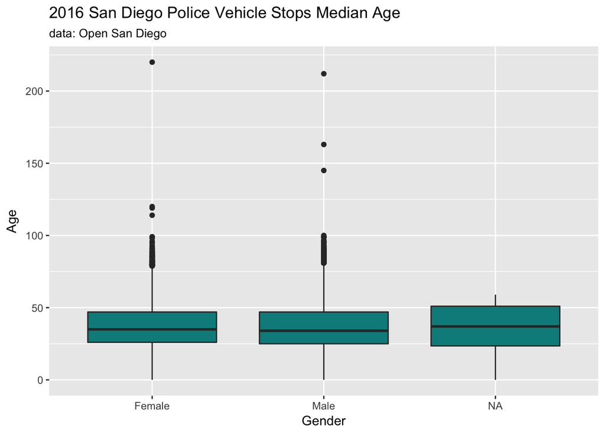

```r
ggplot(data = stops, aes(y = subject_age, x = subject_sex)) +
  geom_boxplot(fill = "cyan4") +
  scale_x_discrete("Gender", labels = c("M" = "Male", "F" = "Female", "NA")) +
  scale_y_continuous("Age") +
  labs(title = "2016 San Diego Police Vehicle Stops Median Age",
       subtitle = "data: Open San Diego")
```

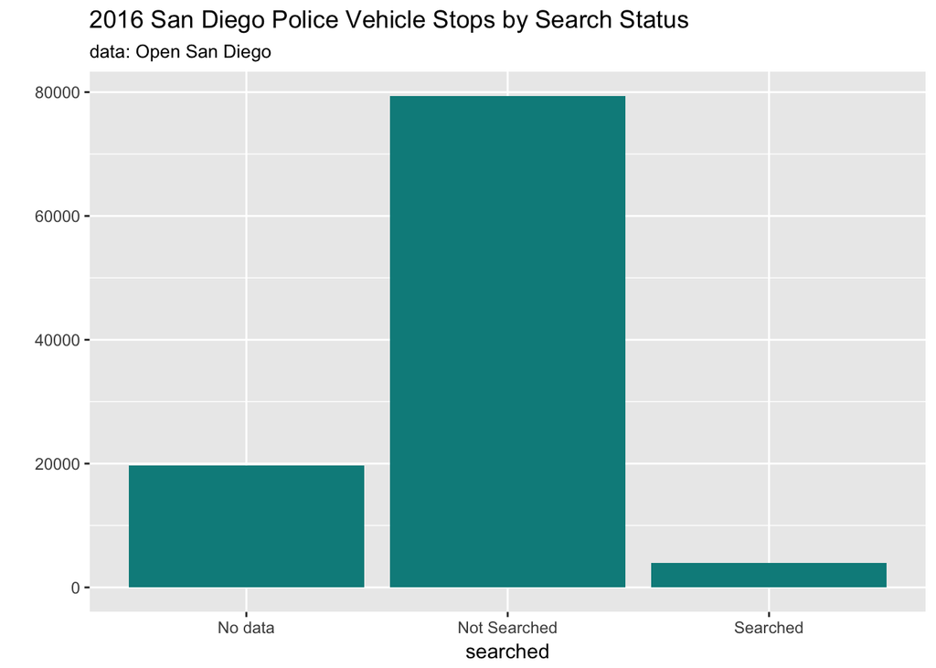

```r
ggplot(data = stops, aes(x = searched)) +
  geom_bar(fill = "cyan4") +
  scale_x_discrete("searched", labels = c("N" = "Not Searched",
                                          "Y" = "Searched", "No data")) +
  labs(title = "2016 San Diego Police Vehicle Stops by Search Status",
       subtitle = "data: Open San Diego",
       x = "Was the subject searched?",
       y = "")
```

When comparing the causes for the stops, we only considered the causes that had more than 10 instances.

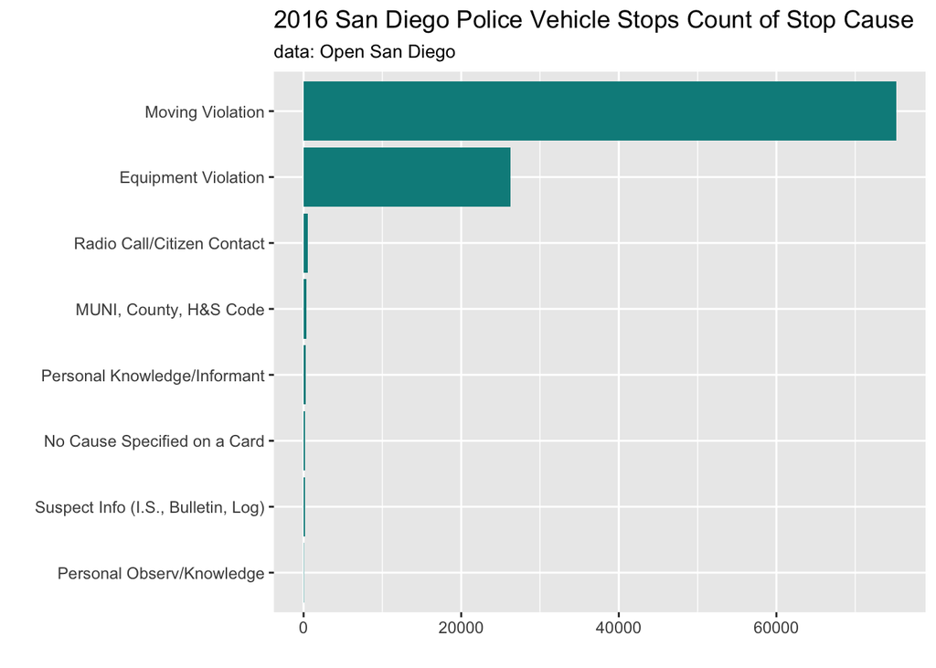

```r
count(stops, stop_cause) %>%
  filter(n > 10) %>%
  ggplot(aes(x = reorder(stop_cause, n), y = n)) +
  geom_bar(stat = "identity", fill = "cyan4") +
  coord_flip() +
  labs(title = "2016 San Diego Police Vehicle Stops Count of Stop Cause",
       subtitle = "data: Open San Diego",
       x = "",
       y = "")
```

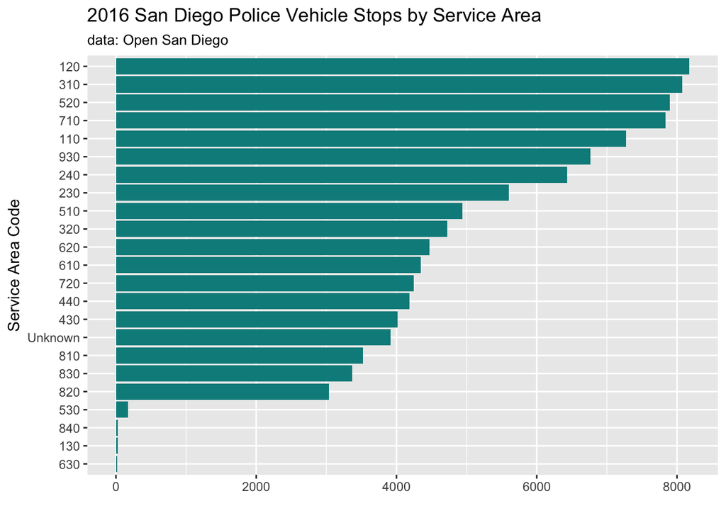

```r
ggplot(stops, aes(x = reorder(service_area, service_area,
                              function(x) {length(x)}))) +
  geom_bar(fill = "cyan4") +
  coord_flip() +
  labs(title = "2016 San Diego Police Vehicle Stops by Service Area",
       subtitle = "data: Open San Diego",
       x = "Service Area Code",
       y = "")
```